# Homework8

Ilaria Coero Borga

2023-03-22

```r
library(ggplot2) # for graphics
library(MASS)
library(dplyr)
library(rlang)
library(tidyverse)
```

```r
# for maximum likelihood estimation
# quick and dirty, a truncated normal distribution to work on the solution set
z<-PlantGrowth
str(z$group)
```

```
##  Factor w/ 3 levels "ctrl","trt1",..: 1 1 1 1 1 1 1 1 1 1 ...
```

```r
summary(z)
```

```
##      weight       group
##  Min.   :3.590   ctrl:10
##  1st Qu.:4.550   trt1:10
##  Median :5.155   trt2:10
##  Mean   :5.073
##  3rd Qu.:5.530
##  Max.   :6.310
```

```r
#dividing the subset groups
ControlData<- filter(z, group=="ctrl") #10 obs of 2 variables
mean(ControlData$weight) #5.032
```

```
## [1] 5.032
```

```r
sd(ControlData$weight) #0.583
```

```
## [1] 0.5830914
```

```r
Treatm1<-filter(z,group=="trt1") #10 obs of 2 variables
mean(Treatm1$weight) #4.661
```

```
## [1] 4.661
```

```r
sd(Treatm1$weight) #0.794
```

```
## [1] 0.7936757
```

```r
Treatm2<-filter(z,group=="trt2") #10 obs of 2 variables
mean(Treatm2$weight) #5.526
```

```
## [1] 5.526
```

```r
sd(Treatm2$weight) #0.446
```

```
## [1] 0.4425733
```

Now we generate a fake dataset based on my parameters taking for granted that we have a normal distribution

```r
NewControl <-rnorm(n=10, mean=5.032,sd=0.583)
NewTreatm1 <-rnorm(n=10, mean=4.661,sd=0.794)
NewTreatm2 <-rnorm(n=10, mean=5.526,sd=0.446)
dFrame <- data.frame(NewControl,NewTreatm1,NewTreatm2,stringsAsFactors=FALSE)
dFrame<-pivot_longer(dFrame, cols=c(NewControl,NewTreatm1,NewTreatm2), names_to="Treatment",values_to="weight")
print(dFrame)
```

```
## # A tibble: 30 × 2
##    Treatment  weight
##    <chr>       <dbl>
##  1 NewControl   5.27
##  2 NewTreatm1   5.46
##  3 NewTreatm2   4.94
##  4 NewControl   5.26
##  5 NewTreatm1   4.63
##  6 NewTreatm2   5.25
##  7 NewControl   5.95
##  8 NewTreatm1   4.77
##  9 NewTreatm2   4.90
## 10 NewControl   5.27
## # … with 20 more rows
```

```r
str(dFrame)
```

```
## tibble [30 × 2] (S3: tbl_df/tbl/data.frame)
##  $ Treatment: chr [1:30] "NewControl" "NewTreatm1" "NewTreatm2" "NewControl" ...
##  $ weight   : num [1:30] 5.27 5.46 4.94 5.26 4.63 ...
```

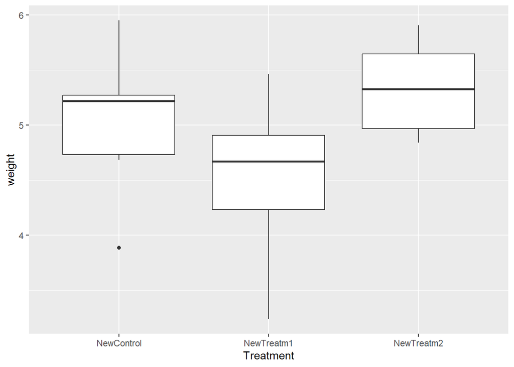

```r
#now we have our fake dataset and we want to do a graph with that and analyze some data
ggplot(dFrame, aes(x=Treatment,y=weight))+geom_boxplot()
```

```r
#this is a useful graph
anova<-aov(weight~Treatment, data=dFrame)
summary(anova)
```

```
##             Df Sum Sq Mean Sq F value Pr(>F)
## Treatment    2  3.282  1.6412   5.422 0.0105 *
## Residuals   27  8.173  0.3027
## ---
## Signif. codes:  0 '***' 0.001 '**' 0.01 '*' 0.05 '.' 0.1 ' ' 1
```

My anova is significant but if I run multiple times it changes–> results are very variable! 1st ANOVA=0.0415 2nd ANOVA=0.00112 3rd ANOVA=0.000467 So now I play a bit around my parameters to understand if and how my results change as well. Let’s see what happens if I change the sample size, making it 100 instead of 10

```
##              Df Sum Sq Mean Sq F value Pr(>F)
## Treatment     2  41.58  20.791   52.79 <2e-16 ***
## Residuals   297 116.97   0.394
## ---
## Signif. codes:  0 '***' 0.001 '**' 0.01 '*' 0.05 '.' 0.1 ' ' 1
```

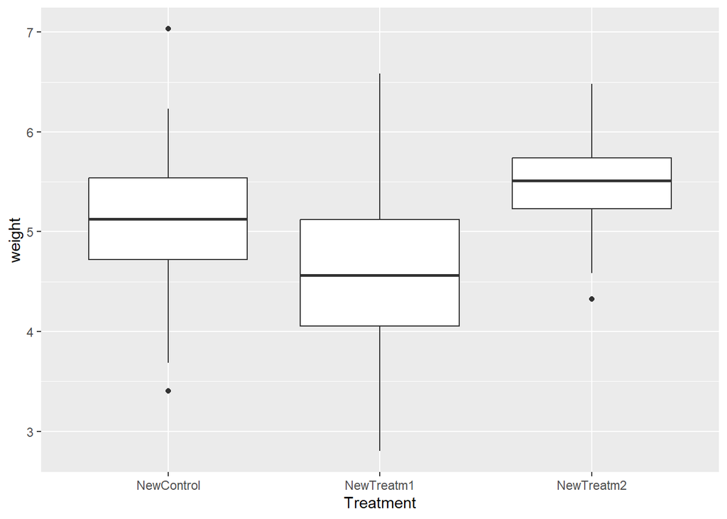

So now, my ANOVA gives me a p-value (<2e-16) that is very significant. I know that I should probably extend the sample size and collect more data to have a stronger effect to be shown! But what about the mean? I’m going to change the mean and leave the sample size as before. I will low down the mean of the NewControl by 2 units

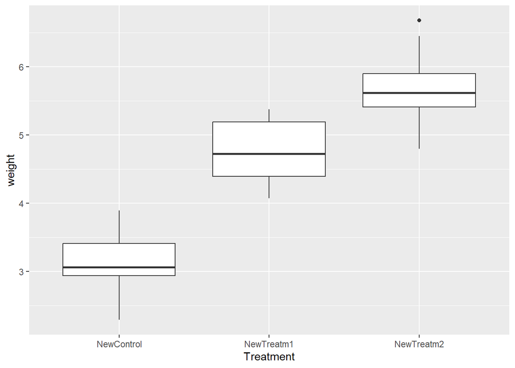

```
##             Df Sum Sq Mean Sq F value   Pr(>F)
## Treatment    2  32.50  16.248   62.88 6.91e-11 ***
## Residuals   27   6.98   0.258
## ---
## Signif. codes:  0 '***' 0.001 '**' 0.01 '*' 0.05 '.' 0.1 ' ' 1
```

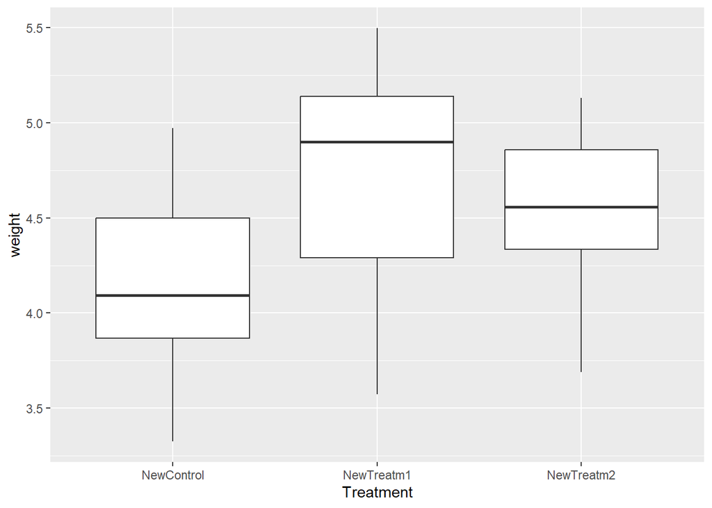

```
##             Df Sum Sq Mean Sq F value Pr(>F)
## Treatment    2  1.349  0.6747    2.18  0.133
## Residuals   27  8.356  0.3095
```

Alternatively, for the effect sizes you originally hypothesized, what is the minimum sample size you would need in order to detect a statistically significant effect? Again, run the model a few times with the same parameter set to get a feeling for the effect of random variation in the data Lowering down of 2 units the sample size can become not significant, for example!

```
##             Df Sum Sq Mean Sq F value Pr(>F)
## Treatment    2  1.731  0.8653   2.317  0.123
## Residuals   21  7.843  0.3735
```